# Introduction to Python Project : FoodHub Data Analysis

### A company named Foodhub wants to analyze the stored data of the customers with an objective to get an fair idea of the demand of multiple restaurants so that Foodhub can offer better customer experience.

### Data Dictionary

# Data Dictionary is given below

1. order_id
2. customer_id
3. restaurant_name
4. cuisine_type
5. cost_of_the_order
6. day_of_the_week
7. rating
8. food_preparation_time
9. delivery_time

### Let us start by importing the required libraries

```python
# Write your code here to import necessary libraries for the project
import pandas as pd
import numpy as np

import matplotlib.pyplot as plt
import seaborn as sns

%matplotlib inline
sns.set(style ='whitegrid')
```

### Understanding the structure of the data

```python
from google.colab import drive
drive.mount('/content/drive')
```

```python
# uncomment and run the following lines for Google Colab
from google.colab import drive
drive.mount('/content/drive')
```

```python
# Write your code here to read the data
df = pd.read_csv('/content/drive/MyDrive/Colab Notebooks/foodhub_order.csv')
```

```python
# Write your code here to view the first 5 rows
print(df.head())
```

```
   order_id  customer_id            restaurant_name cuisine_type  \
0   1477147       337525                    Hangawi       Korean
1   1477685       358141  Blue Ribbon Sushi Izakaya     Japanese
2   1477070        66393                Cafe Habana      Mexican
3   1477334       106968  Blue Ribbon Fried Chicken     American
4   1478249        76942           Dirty Bird to Go     American

   cost_of_the_order day_of_the_week     rating  food_preparation_time  \
0              30.75         Weekend  Not given                     25
1              12.08         Weekend  Not given                     25
2              12.23         Weekday          5                     23
3              29.20         Weekend          3                     25
4              11.59         Weekday          4                     25

   delivery_time
0             20
1             23
2             28
3             15
4             24
```

### **Question 1:** How many rows and columns are present in the data? [0.5 mark]

```python
df.shape
```

```
(1898, 9)
```

#### Observations:

# There are 1898 rows and 9 columns in the given dataset

### **Question 2:** What are the datatypes of the different columns in the dataset? (The info() function can be used) [0.5 mark]

```python
# Write your code here
df.info()
```

```
<class 'pandas.core.frame.DataFrame'>
RangeIndex: 1898 entries, 0 to 1897
Data columns (total 9 columns):
 #   Column                 Non-Null Count  Dtype
---  ------                 --------------  -----
 0   order_id               1898 non-null   int64
 1   customer_id            1898 non-null   int64
 2   restaurant_name        1898 non-null   object
 3   cuisine_type           1898 non-null   object
 4   cost_of_the_order      1898 non-null   float64
 5   day_of_the_week        1898 non-null   object
 6   rating                 1898 non-null   object
 7   food_preparation_time  1898 non-null   int64
 8   delivery_time          1898 non-null   int64
dtypes: float64(1), int64(4), object(4)
memory usage: 133.6+ KB
```

#### Observations:

# For all types of data columns there are no null values for any of them.

# Data type present are - 1 float(64), 4 int(64), 4 object

# Memory usage is approx 133.6 KB

### **Question 3:** Are there any missing values in the data? If yes, treat them using an appropriate method. [1 mark]

```python
# Write your code here
missing_values = df.isnull().sum()
print(missing_values)
```

```
order_id                 0
customer_id              0
restaurant_name          0
cuisine_type             0
cost_of_the_order        0
day_of_the_week          0
rating                   0
food_preparation_time    0
delivery_time            0
dtype: int64
```

#### Observations:

# There are no missing values in the dataset

### **Question 4:** Check the statistical summary of the data. What is the minimum, average, and maximum time it takes for food to be prepared once an order is placed? [2 marks]

```python
# Write your code here
stats_summary = df.describe()
print(stats_summary)

stats_prep_time = stats_summary.loc[["min", "mean", "max"], "food_preparation_time"]
print(stats_prep_time)
```

```
           order_id    customer_id  cost_of_the_order  food_preparation_time  \
count  1.898000e+03    1898.000000        1898.000000            1898.000000
mean   1.477496e+06  171168.478398          16.498851              27.371970
std    5.480497e+02  113698.139743           7.483812               4.632481
min    1.476547e+06    1311.000000           4.470000              20.000000
25%    1.477021e+06   77787.750000          12.080000              23.000000
50%    1.477496e+06  128600.000000          14.140000              27.000000
75%    1.477970e+06  270525.000000          22.297500              31.000000
max    1.478444e+06  405334.000000          35.410000              35.000000

       delivery_time
count    1898.000000
mean       24.161749
std         4.972637
min        15.000000
25%        20.000000
50%        25.000000
75%        28.000000
max        33.000000
min     20.00000
mean    27.37197
max     35.00000
Name: food_preparation_time, dtype: float64
```

#### Observations:

# Minimum time = 20 minutes

# Maximum time = 35 minutes

# Average or mean time = 27.37 minutes

### **Question 5:** How many orders are not rated? [1 mark]

```python
# Write the code here
not_rated = (df['rating'] == 'Not given').sum()
print(not_rated)
```

```
736
```

#### Observations:

# For 736 orders rating has not been given.

### Exploratory Data Analysis (EDA)

### Univariate Analysis

```python
#Some basic analysis to understand the data given

#Number of restaurants
total_restaurants = df['restaurant_name'].nunique()
print(f"Total number of restaurants: {total_restaurants}")

#number of cuisines with order values
num_cuisines = df['cuisine_type'].value_counts()
print(num_cuisines)
```

```
Total number of restaurants: 178
cuisine_type
American          584
Japanese          470
Italian           298
Chinese           215
Mexican            77
Indian             73
Middle Eastern     49
Mediterranean      46
Thai               19
French             18
Southern           17
Korean             13
Spanish            12
Vietnamese          7
Name: count, dtype: int64
```

# There are total 178 restaurants and 14 types of cuisines. Most ordered is American and least ordered is Vietnamese.

### **Question 6:** Explore all the variables and provide observations on their distributions. (Generally, histograms, boxplots, countplots, etc. are used for univariate exploration.) [9 marks]

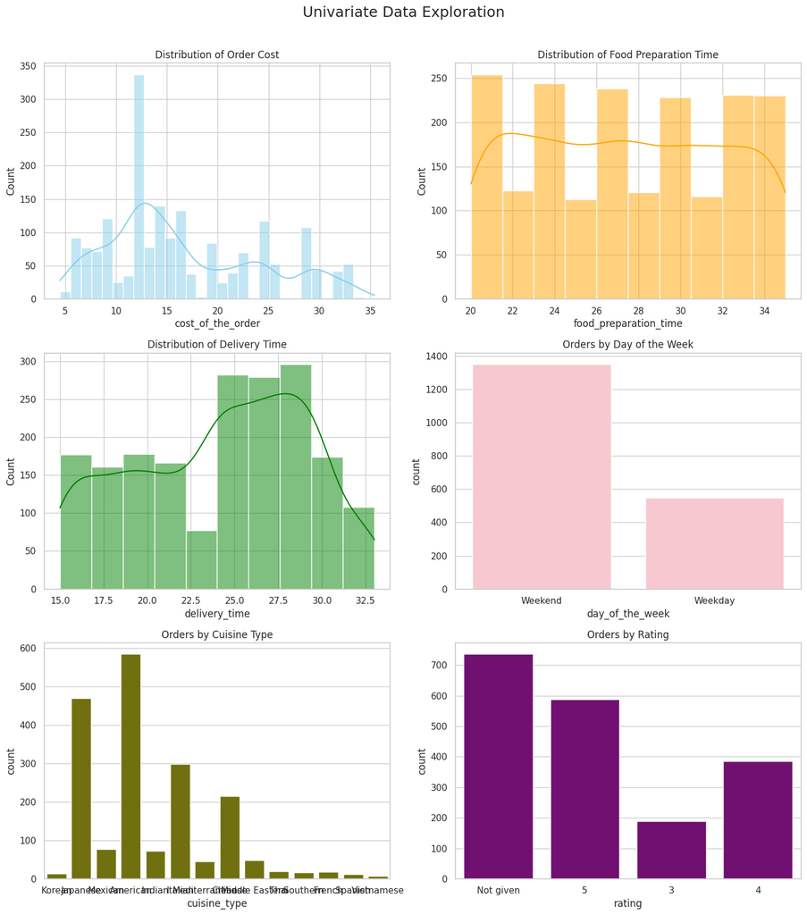

```python
# Write the code here
#import required libraries
import pandas as pd
import numpy as np


import matplotlib.pyplot as plt
import seaborn as sns

sns.set(style ='whitegrid')


#create sub-plots for numerical and categorical columns separately
fig, axes =plt.subplots(3, 2, figsize=(14, 16))
fig.suptitle('Univariate Data Exploration', fontsize=18)

#Numerical Variables
sns.histplot(df['cost_of_the_order'], bins=30, kde=True, ax=axes[0, 0], color='skyblue')
axes[0, 0].set_title('Distribution of Order Cost')

sns.histplot(df['food_preparation_time'], bins=10, kde=True, ax=axes[0, 1], color='orange')
axes[0, 1].set_title('Distribution of Food Preparation Time')

sns.histplot(df['delivery_time'], bins=10, kde=True, ax=axes[1, 0], color='green')
axes[1, 0].set_title('Distribution of Delivery Time')

#Categorical Variables
sns.countplot(data=df, x='day_of_the_week', ax=axes[1, 1], color='pink')
axes[1, 1].set_title('Orders by Day of the Week')

sns.countplot(data=df, x='cuisine_type', ax=axes[2, 0], color='olive')
axes[2, 0].set_title('Orders by Cuisine Type')

sns.countplot(data=df, x='rating', ax=axes[2, 1], color='purple')
axes[2, 1].set_title('Orders by Rating')

plt.tight_layout(rect=[0, 0, 1, 0.97])
plt.show()
```

### **Question 7**: Which are the top 5 restaurants in terms of the number of orders received? [1 mark]

```python
# Write the code here
top_5_restaurants = df['restaurant_name'].value_counts().head(5)
print(top_5_restaurants)
```

```
restaurant_name
Shake Shack                  219
The Meatball Shop            132
Blue Ribbon Sushi            119
Blue Ribbon Fried Chicken     96
Parm                          68
Name: count, dtype: int64
```

#### Observations:

# The top 5 restaurants on the basis of number of orders received are given below

restaurant_name Order Count Shake Shack 219 The Meatball Shop 132 Blue Ribbon Sushi 119 Blue Ribbon Fried Chicken 96 Parm 68

### **Question 8**: Which is the most popular cuisine on weekends? [1 mark]

```python
# Write the code here
#Find weekend orders
weekend_orders = df[df['day_of_the_week'] == 'Weekend']

#Find the most popular cuisine on weekends
most_popular_cuisine_weekend = weekend_orders['cuisine_type'].value_counts().idxmax()
print(most_popular_cuisine_weekend)
```

```
American
```

#### Observations:

# The most popular cuisine on the weekends is American with 415 orders placed for the same.

### **Question 9**: What percentage of the orders cost more than 20 dollars? [2 marks]

```python
# Write the code here
#Find orders that cost more than 20 dollars to the customers
total_orders = len(df)
orders_above_20 = (df['cost_of_the_order'] > 20).sum()
print(orders_above_20)

#Find the percentage of orders above 20 dollars
percentage_above_20 = (orders_above_20 /total_orders) * 100
print(percentage_above_20)
```

```
555
29.24130663856691
```

#### Observations:

# Total number of orders placed above $20 are 555 and their percentage is 29.24%

### **Question 10**: What is the mean order delivery time? [1 mark]

```python
# Write the code here
mean_order_delivery_time = df['delivery_time'].mean()
print(f"mean_order_delivery_time: {mean_delivery_time:.2f} minutes")
```

[output not shown]

#### Observations:

# The mean order delivery time is 24.16 minutes.

### **Question 11:** The company has decided to give 20% discount vouchers to the top 3 most frequent customers. Find the IDs of these customers and the number of orders they placed. [1 mark]

```python
# Write the code here
#Find the top 3 frequent customers and their IDs and number of orders they have placed
top_3_customers = df['customer_id'].value_counts().head(3)
print(top_3_customers)
```

```
customer_id
52832    13
47440    10
83287     9
Name: count, dtype: int64
```

#### Observations:

# The top 3 customer by IDs and orders eligible for 20% discount vouchers are below:

1. Cust_ID 52832 placed 13 orders
2. Cust_ID 47440 placed 10 orders
3. Cust_ID 83287 placed 9 orders

### **Question 12**: Perform a multivariate analysis to explore relationships between the important variables in the dataset. (It is a good idea to explore relations between numerical variables as well as relations between numerical and categorical variables) [10 marks]

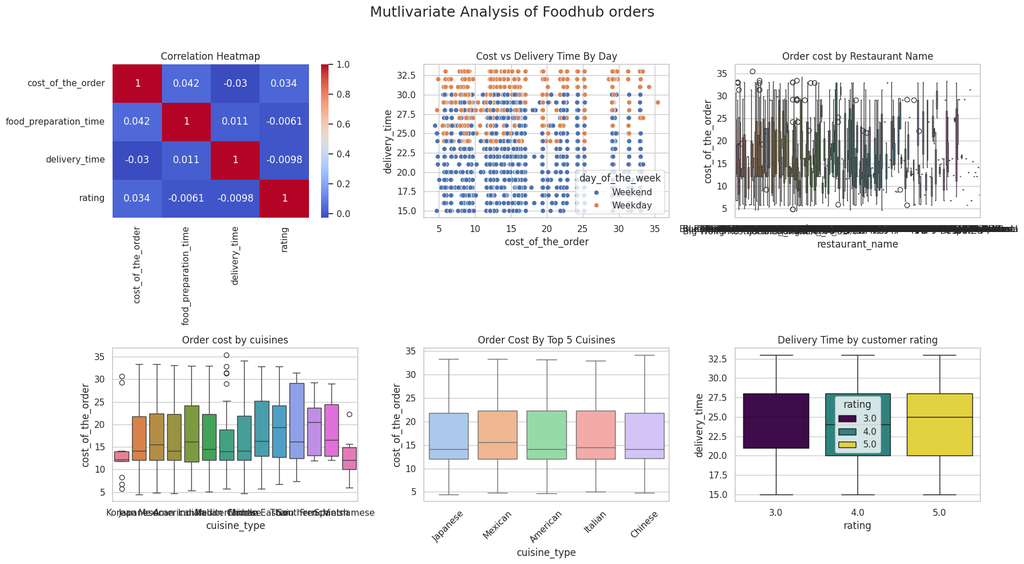

```python
# Write the code here
import pandas as pd
import seaborn as sns
import matplotlib.pyplot as plt

# Load the dataset
df = pd.read_csv('/content/drive/MyDrive/Colab Notebooks/foodhub_order.csv')

#visual style
sns.set(style="whitegrid")

#convert rating to numerical value, replace 'Not given' with NaN
df['rating']=pd.to_numeric(df['rating'], errors='coerce')

#Create a visual with multiple subplots
fig, axes=plt.subplots(2, 3, figsize=(18, 10),)
fig.suptitle('Mutlivariate Analysis of Foodhub orders', fontsize=18)

#Correlation heatmap for numerical values
corr = df[['cost_of_the_order', 'food_preparation_time', 'delivery_time', 'rating']].corr()
sns.heatmap(corr, annot=True, cmap='coolwarm', ax=axes[0, 0])
axes[0, 0].set_title('Correlation Heatmap')

#Scatterplot: Cost vs Delivery Time
sns.scatterplot(data=df, x='cost_of_the_order', y='delivery_time', hue='day_of_the_week', ax=axes[0, 1])
axes[0, 1].set_title('Cost vs Delivery Time By Day')

#Boxplot: Cost vs Restaurant name
sns.boxplot(data=df, x='restaurant_name', y='cost_of_the_order', hue='restaurant_name', ax=axes[0, 2])
axes[0, 2].set_title('Order cost by Restaurant Name')

#Boxplot : Order cost by cuisines
sns.boxplot(data=df, x='cuisine_type', y='cost_of_the_order', hue='cuisine_type', ax=axes[1, 0])
axes[1, 0].set_title('Order cost by cuisines')

#Boxplot : Order cost by op 5 cuisines (Top 5)
Top_5_cuisines = df['cuisine_type'].value_counts().nlargest(5).index
sns.boxplot(data=df[df['cuisine_type'].isin(Top_5_cuisines)],
            x='cuisine_type', y='cost_of_the_order', hue='cuisine_type', ax=axes[1, 1], palette='pastel')
axes[1, 1].set_title('Order Cost By Top 5 Cuisines')
axes[1, 1].tick_params(axis='x', labelrotation=45)

#Boxplot : Delivery Time by customer rating
sns.boxplot(data=df, x='rating', y='delivery_time', hue='rating', ax=axes[1, 2], palette='viridis')
axes[1, 2].set_title('Delivery Time by customer rating')


plt.tight_layout(rect=[0, 0, 1, 0.96])
plt.show()
```

### **Question 13:** The company wants to provide a promotional offer in the advertisement of the restaurants. The condition to get the offer is that the restaurants must have a rating count of more than 50 and the average rating should be greater than 4. Find the restaurants fulfilling the criteria to get the promotional offer. [3 marks]

```python
# Write the code here
#convert rating to numerical value ('Not given' to NaN)
df['rating'] = pd.to_numeric(df['rating'], errors='coerce')

#Calculate rating count and average and group them by restaurant
rating_summary=df.groupby('restaurant_name')['rating'].agg(['count', 'mean'])

#Applying the promotional condition
eligible_restaurants = rating_summary[(rating_summary['count'] > 50) & (rating_summary['mean'] > 4)]

#Result
print(eligible_restaurants)
```

```
                           count      mean
restaurant_name
Blue Ribbon Fried Chicken     64  4.328125
Blue Ribbon Sushi             73  4.219178
Shake Shack                  133  4.278195
The Meatball Shop             84  4.511905
```

#### Observations:

# As per the derived results the given restaurants have rating count of more than 50 and a rating of greater than 4 :

**Blue Ribbon Fried Chicken** with a rating count of **64** and mean rating of **4.328125**

**Blue Ribbon Sushi** with a rating count of **73** and mean rating of **4.219178**

**Shake Shack** with a rating count of **133** and mean rating of **4.278195**

**The Meatball Shop** with a rating count of **84** and mean rating of **4.511905**